# Iris - analiza danych dla 3 różnych gatunków

[figure not shown]

## Cel zadania

Analiza cech gatunków irysów, ich zależności i różnic oraz wpływu na ostateczną wielkość kwiatu.

## Informacja o danych

Zbiór danych zawiera informacje o trzech gatunkach irysów: Iris setosa, Iris versicolor, i Iris virginica. Dane obejmują pomiary czterech cech: długość i szerokość działki kielicha oraz długość i szerokość płatka. Każdy wiersz w zbiorze danych reprezentuje pojedynczy kwiat, a wartości pomiarów są podane w centymetrach. Zbiór składa się z 150 próbek, po 50 dla każdego gatunku.

## 1. Ogólny przegląd danych

W tym kroku zapoznamy się z podstawową strukturą zbioru danych.

### 1.1. Wczytanie danych z pliku do analizy

Importujemy bibliotekę pandas i wczytujemy zbiór danych z pliku CSV do dalszej analizy.

|  | długość kielicha (sepal length) | szerokość kielicha (sepal width) | długość płatka (petal length) | szerokość płatka (petal width) | klasa (class) |
| --- | --- | --- | --- | --- | --- |
| 0 | 5.1 | 3.5 | 1.4 | 0.2 | Iris-setosa |
| 1 | 4.9 | 3.0 | 1.4 | 0.2 | Iris-setosa |
| 2 | 4.7 | 3.2 | 1.3 | 0.2 | Iris-setosa |
| 3 | 4.6 | 3.1 | 1.5 | 0.2 | Iris-setosa |
| 4 | 5.0 | 3.6 | 1.4 | 0.2 | Iris-setosa |
| ... | ... | ... | ... | ... | ... |
| 145 | 6.7 | 3.0 | 5.2 | 2.3 | Iris-virginica |
| 146 | 6.3 | 2.5 | 5.0 | 1.9 | Iris-virginica |
| 147 | 6.5 | 3.0 | 5.2 | 2.0 | Iris-virginica |
| 148 | 6.2 | 3.4 | 5.4 | 2.3 | Iris-virginica |
| 149 | 5.9 | 3.0 | 5.1 | 1.8 | Iris-virginica |

150 rows × 5 columns

### 1.2. Losowe 10 rekordów

Wyświetlamy losowe próbki danych, aby sprawdzić ich strukturę i różnorodność.

|  | długość kielicha (sepal length) | szerokość kielicha (sepal width) | długość płatka (petal length) | szerokość płatka (petal width) | klasa (class) |
| --- | --- | --- | --- | --- | --- |
| 68 | 6.2 | 2.2 | 4.5 | 1.5 | Iris-versicolor |
| 130 | 7.4 | 2.8 | 6.1 | 1.9 | Iris-virginica |
| 24 | 4.8 | 3.4 | 1.9 | 0.2 | Iris-setosa |
| 67 | 5.8 | 2.7 | 4.1 | 1.0 | Iris-versicolor |
| 97 | 6.2 | 2.9 | 4.3 | 1.3 | Iris-versicolor |
| 56 | 6.3 | 3.3 | 4.7 | 1.6 | Iris-versicolor |
| 110 | 6.5 | 3.2 | 5.1 | 2.0 | Iris-virginica |
| 4 | 5.0 | 3.6 | 1.4 | 0.2 | Iris-setosa |
| 17 | 5.1 | 3.5 | 1.4 | 0.3 | Iris-setosa |
| 85 | 6.0 | 3.4 | 4.5 | 1.6 | Iris-versicolor |

### 1.3. Liczba wartości unikatowych w poszczególnych kolumnach

Sprawdzamy ile unikalnych wartości zawiera każda kolumna, co pozwala zrozumieć zróżnicowanie danych.

```
długość kielicha (sepal length)     35
szerokość kielicha (sepal width)    23
długość płatka (petal length)       43
szerokość płatka (petal width)      22
klasa (class)                        3
dtype: int64
```

### 1.4. Podstawowe statystyki dla kolumn numerycznych

Wyświetlamy podstawowe statystyki opisowe (średnia, mediana, odchylenie standardowe, min, max) dla wszystkich parametrów.

|  | count | mean | std | min | 25% | 50% | 75% | max |
| --- | --- | --- | --- | --- | --- | --- | --- | --- |
| długość kielicha (sepal length) | 150.0 | 5.843333 | 0.828066 | 4.3 | 5.1 | 5.80 | 6.4 | 7.9 |
| szerokość kielicha (sepal width) | 150.0 | 3.054000 | 0.433594 | 2.0 | 2.8 | 3.00 | 3.3 | 4.4 |
| długość płatka (petal length) | 150.0 | 3.758667 | 1.764420 | 1.0 | 1.6 | 4.35 | 5.1 | 6.9 |
| szerokość płatka (petal width) | 150.0 | 1.198667 | 0.763161 | 0.1 | 0.3 | 1.30 | 1.8 | 2.5 |

Wyświetlamy dodatkową tabelę, gdzie pokazujemy różnice między największymi a najmniejszymi wartościami dla każdej cechy (wart. max - wart.min), dzięki czemu sprawdzimy które cechy mają największe różnice w wartościach, a które są najabrdziej zawężone.

|  | parametr | max-min |
| --- | --- | --- |
| A | długość kielicha | 3.6 |
| B | szerokość kielicha | 2.4 |
| C | długość płatka | 5.9 |
| D | szerokość płatka | 2.4 |

**Wniosek:** Długość zarówno płatka jak i kielicha są cechami najbardziej zmiennymi oraz z największą rozpiętością między wartością maksymalną a minimalną. Szerokości kielicha i płatka są do siebie bardziej zbliżone niezależnie od klasy kwiatu.

### 1.5. Dane statystyczne dla każdej z kolumn, pogrupowane według klas kwiatu

Porównujemy parametry między trzema gatunkami irysów aby zidentyfikować różnice między nimi.

Wyróżnienia kolorystyczne:

Kolor niebieski - wartości najmniejsze w danym wierszu

Kolor czerwowny - wartości największe w danym wierszu

#### Średnia

| klasa (class) | Iris-setosa | Iris-versicolor | Iris-virginica |
| --- | --- | --- | --- |
| długość kielicha (sepal length) | 5.006000 | 5.936000 | 6.588000 |
| szerokość kielicha (sepal width) | 3.418000 | 2.770000 | 2.974000 |
| długość płatka (petal length) | 1.464000 | 4.260000 | 5.552000 |
| szerokość płatka (petal width) | 0.244000 | 1.326000 | 2.026000 |

#### Mediana

| klasa (class) | Iris-setosa | Iris-versicolor | Iris-virginica |
| --- | --- | --- | --- |
| długość kielicha (sepal length) | 5.000000 | 5.900000 | 6.500000 |
| szerokość kielicha (sepal width) | 3.400000 | 2.800000 | 3.000000 |
| długość płatka (petal length) | 1.500000 | 4.350000 | 5.550000 |
| szerokość płatka (petal width) | 0.200000 | 1.300000 | 2.000000 |

#### Wartości maksymalne

| klasa (class) | Iris-setosa | Iris-versicolor | Iris-virginica |
| --- | --- | --- | --- |
| długość kielicha (sepal length) | 5.800000 | 7.000000 | 7.900000 |
| szerokość kielicha (sepal width) | 4.400000 | 3.400000 | 3.800000 |
| długość płatka (petal length) | 1.900000 | 5.100000 | 6.900000 |
| szerokość płatka (petal width) | 0.600000 | 1.800000 | 2.500000 |

#### Wartości minimalne

| klasa (class) | Iris-setosa | Iris-versicolor | Iris-virginica |
| --- | --- | --- | --- |
| długość kielicha (sepal length) | 4.300000 | 4.900000 | 4.900000 |
| szerokość kielicha (sepal width) | 2.300000 | 2.000000 | 2.200000 |
| długość płatka (petal length) | 1.000000 | 3.000000 | 4.500000 |
| szerokość płatka (petal width) | 0.100000 | 1.000000 | 1.400000 |

**Wniosek:** Z uśrednionych parametrów z każdej klasy zarysowuje się zależność, że najmniejszym kwiatem jest Iris-setosa, średnim jest Iris-versicolor, a największym Iris-virginica. Bardziej szczegółowo będzie to wykazane w kolejnych punktach.

## 2. Analiza brakujących wartości

Sprawdzamy jakość danych pod kątem kompletności i duplikatów.

### 2.1. Wartości brakujące dla każdej z kolumn

Liczymy ile wartości brakujących (NULL) występuje w każdej kolumnie.

```
długość kielicha (sepal length)     0
szerokość kielicha (sepal width)    0
długość płatka (petal length)       0
szerokość płatka (petal width)      0
klasa (class)                       0
dtype: int64
```

### 2.2. Rekordy zduplikowane lub identyczne

Sprawdzamy czy w zbiorze występują identyczne rekordy, które mogą być wynikiem błędu w danych.

|  | długość kielicha (sepal length) | szerokość kielicha (sepal width) | długość płatka (petal length) | szerokość płatka (petal width) | klasa (class) |
| --- | --- | --- | --- | --- | --- |
| 34 | 4.9 | 3.1 | 1.5 | 0.1 | Iris-setosa |
| 37 | 4.9 | 3.1 | 1.5 | 0.1 | Iris-setosa |
| 142 | 5.8 | 2.7 | 5.1 | 1.9 | Iris-virginica |

**Wniosek:**

- Dane nie mają wartości brakujących.
- Dane mają 3 duplikaty, jednakże nie będziemy ich usuwać, ponieważ prawdopodobne jest, że wśród 150 kwiatów rzeczywiście mogą zdarzyć się kwiaty o identycznych parametrach.

## 3. Analiza pojedynczych zmiennych

Wizualizujemy rozkład każdej zmiennej numerycznej za pomocą histogramów.

### 3.1. Histogram dla każdej z kolumn numerycznych

Tworzymy histogramy dla wszystkich parametrów, aby zobaczyć ogólny rozkład wartości w całym zbiorze danych.

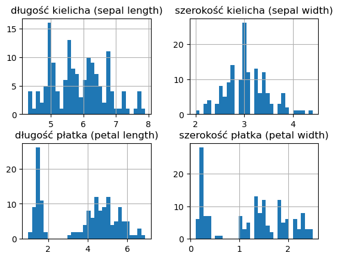

**Wniosek:** Z powyżej przedstawionych histogramów nie wyczytamy zbyt wiele zależności, ponieważ parametry kwiatu różnią się w zależności od tego, do jakiej klasy przynależą. Dlatego lepszym sposobem na wizualizację parametrów będą histogramy z podziałem na klasy.

### 3.2. Histogram długości płatka z podziałem na klasy

Przedstawiamy rozkład długości płatka osobno dla każdego gatunku, aby porównać ich różnice.

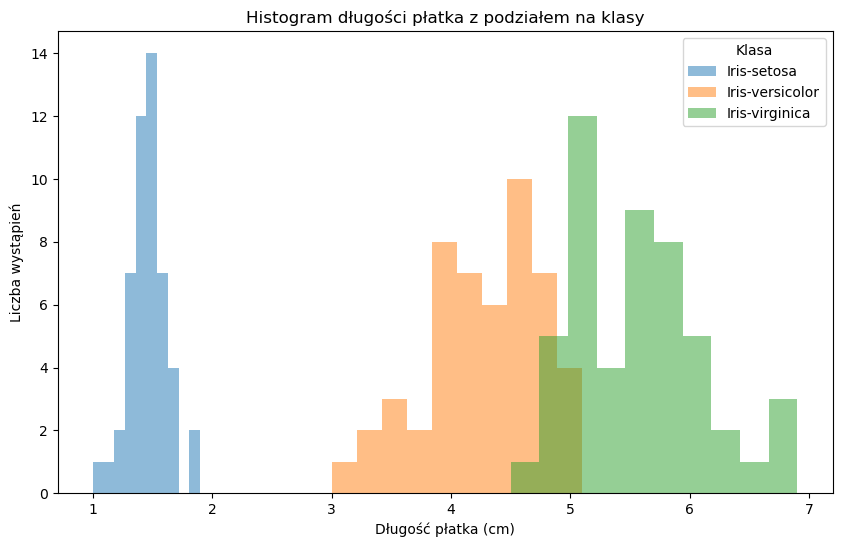

**Wniosek:** Klasa Iris-setosa zdecydowanie odstaje od pozostałych 2 klas pod względem długości płatka.

### 3.3. Histogram szerokości płatka z podziałem na klasy

Przedstawiamy rozkład szerokości płatka osobno dla każdego gatunku, aby porównać ich różnice.

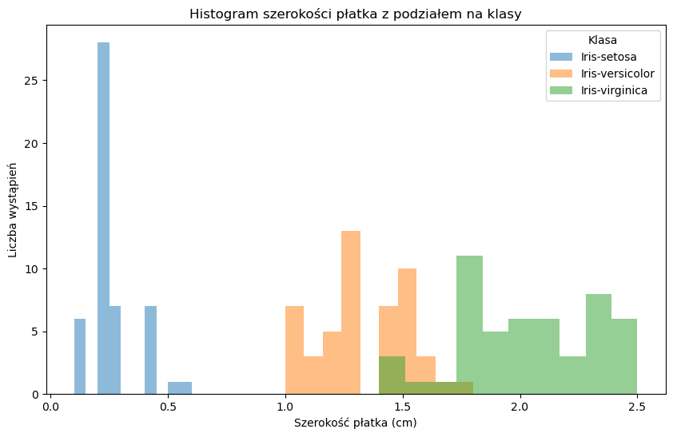

**Wniosek:** Klasa Iris-setosa, podobnie jak w przypadku długości płatka, również ma szerokość płatka znacznie mniejszą niż pozostałe 2 klasy.

### 3.4. Histogram długości kielicha z podziałem na klasy

Przedstawiamy rozkład długości kielicha osobno dla każdego gatunku, aby porównać ich różnice.

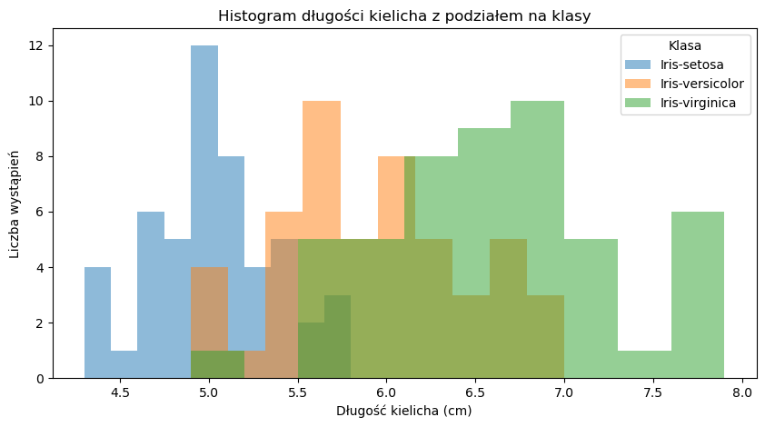

**Wniosek:** Długość kielicha ma mniejsze zróżnicowanie niż wcześniejsze 2 parametry, długości kielicha są bardziej zbliżone do siebie. Jednakże wciąż zostaje zachowana kolejność: Iris-setosa ma najmniejsze wartości, następnie jest Iris-versicolor, a największy jest Iris-virginica.

### 3.5. Histogram szerokości kielicha z podziałem na klasy

Przedstawiamy rozkład szerokości kielicha osobno dla każdego gatunku, aby porównać ich różnice.

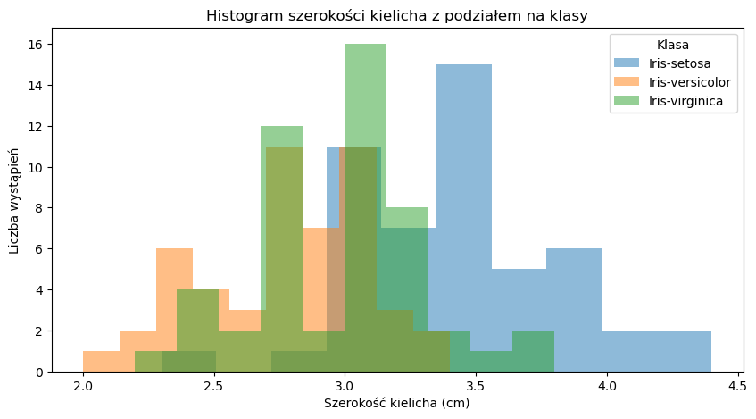

**Wniosek:** Klasa Iris-setosa ma największe parametry szerokości kielicha. To pierwszy parametr, w którym Iris-setosa dominuje nad resztą klas pod względem wielkości. Nie są to jednak jakieś duże różnice – wszystko mieści się w przedziale zaledwie 2,4 cm.

### 3.6. Mediana parametrów dla każdej z klas kwiatu

Przedstawiamy wykres słupkowy z medianą wartości dla każdego gatunku, co pozwala na szybkie porównanie typowych wartości między klasami.

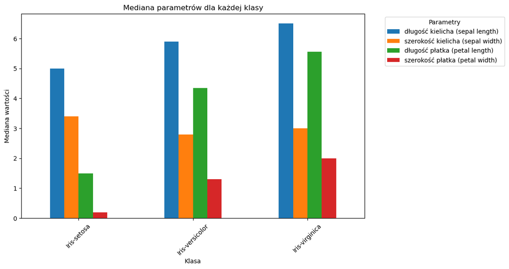

- Iris-setosa ma w 3 parametrach (na 4 badane) najniższe wartości. Jedynie szerokość kielicha Iris-setosa jest wyjątkiem i jest największa wśród wszystkich 3 klas.
- Iris-setosa ma kielich najbardziej zbliżony do kształtu owalnego spośród wszystkich klas, ponieważ długość i szerokość kielicha mają zbliżone wartości.
- Pod względem ogólnej wielkości kwiatu można sklasyfikować poszczególne klasy jako: Iris-setosa (najmniejszy), Iris-versicolor (średni), Iris-virginica (największy).

## 4. Transformacja danych

Dane są czyste, brak konieczności poprawiania danych.

## 5. Relacje między zmiennymi

Badamy zależności między różnymi parametrami kwiatów, aby zrozumieć, które cechy są ze sobą powiązane.

### 5.1. Macierz korelacji między kolumnami

Obliczamy korelację między wszystkimi parametrami numerycznymi i wizualizujemy ją za pomocą mapy cieplnej, aby zobaczyć, które cechy są najbardziej ze sobą powiązane.

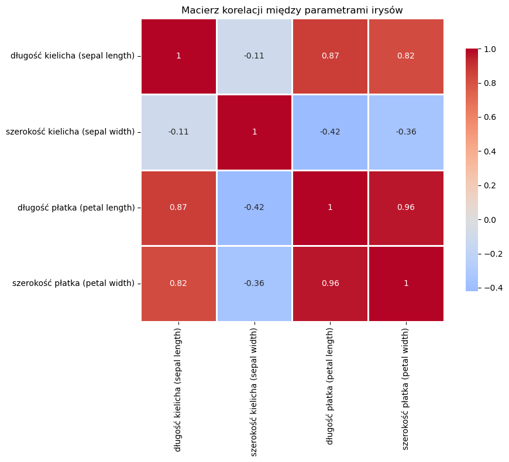

**Wnioski:** Najbardziej skorelowane pary parametrów to:

- Długość płatka z szerokością płatka (0.96) – bardzo silna korelacja, co oznacza że im dłuższy płatek, tym jest również szerszy.
- Długość kielicha z długością płatka (0.87) – silna korelacja, większy kielich to większy płatek.
- Długość kielicha z szerokością płatka (0.82) – silna korelacja.

Wielkość całego kwiatu zależy najbardziej od długości płatka. Długość kielicha jest dobrym predyktorem wielkości całego kwiatu – silnie koreluje z wymiarami płatka. Szerokość kielicha nie jest wyznacznikiem wielkości kwiatu.

### 5.2. Wykres punktowy dla długości i szerokości płatka z podziałem na klasy

Tworzymy wykres rozrzutu (scatter plot), aby zobaczyć zależność między długością a szerokością płatka oraz jak różnią się klasy pod tym względem.

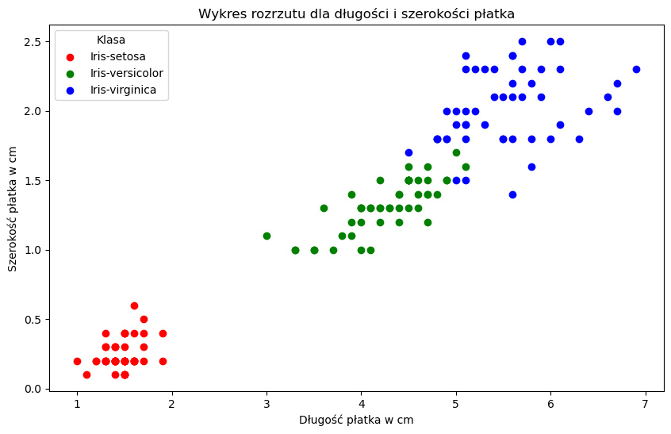

**Wniosek:** Klasa Iris-setosa ma zdecydowanie mniejsze płatki (długość i szerokość) niż pozostałe 2 klasy.

## 6. Wartości odstające

Identyfikujemy wartości odstające (outliers) za pomocą wykresów pudełkowych (box plot).

Tworzymy wykresy pudełkowe dla wszystkich cech, które pokazują medianę, kwartyle oraz wartości odstające dla każdego parametru.

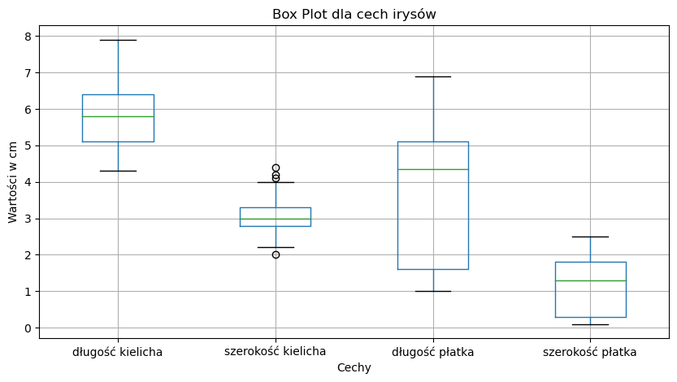

**Wniosek:** Największy rozrzut w wartościach ma parametr długości płatka, wpływ na to niewątpliwie ma klasa Iris-setosa, która ma znacznie krótsze płatki niż pozostałe 2 klasy. Najmniejszy rozrzut wartości występuje w szerokości kielicha, jednakże jako jedyny parametr ma on wartości odstające poza normę.

## 7. Podsumowanie analizy

1. Dokonano analizy 150 pomiarów dla 4 parametrów kwiatu Irisa. Dane były podzielone na 3 klasy kwiatu (po 50 pomiarów dla każdej z klas).
2. Dane były czyste, bez wartości brakujących, jedynie z 3 duplikatami, które jednak mogły nie być wynikiem pomyłki w zapisie danych – duplikaty w tego typu analizie są możliwe.
3. Klasa Iris-setosa zdecydowanie odstaje pod względem długości i szerokości płatka od pozostałych 2 klas. W przypadku długości kielicha wartości są bardziej zbliżone we wszystkich klasach. Natomiast wyjątkowo w szerokości kielicha klasa Iris-setosa nieznacznie dominuje nad resztą klas.
4. Na podstawie przeanalizowanych danych można stwierdzić, że najmniejszym/najdrobniejszym kwiatem jest Iris-setosa, średnim jest Iris-versicolor, a największym Iris-virginica.
5. Wielkość całego kwiatu w największym stopniu zależy od długości płatka (korelacja 0.96 z szerokością płatka). Długość kielicha jest dobrym predyktorem wielkości – silnie koreluje z wymiarami płatka (0.87 i 0.82). Natomiast szerokość kielicha nie ma większego znaczenia co do wielkości całego kwiatu.
6. Największy rozrzut w wartościach ma parametr długości płatka, wpływ na to niewątpliwie ma klasa Iris-setosa, która ma znacznie krótsze płatki niż pozostałe 2 klasy. Najmniejszy rozrzut wartości występuje w szerokości kielicha, jednakże jako jedyny parametr ma on wartości odstające poza normę.
7. Wnioski bardziej szczegółowe znajdują się w niemal każdym podpunkcie powyższej analizy.